# Data Analysis for Ford Gobike System Data by Caleb Denzeil

## Investigation Overview

> The main goal of my investigation was to find out the duration for user types.

## Dataset Overview

> The dataset is quite large, at first their were 183412 rows with 16 features. After wrangling the, number of rows reduced to 174952 and features from 16 to 21. Some of the features that I was intrested in were duration, start time and user type.

## Types of bike Users

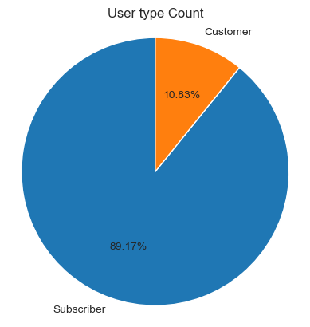

## Distribution for duration

> The histogram depicts the distribution for duration and most users are stacked at 300 to 700 seconds. Meaning that most bikers take approsimately 5 to 11 minutes for their rides

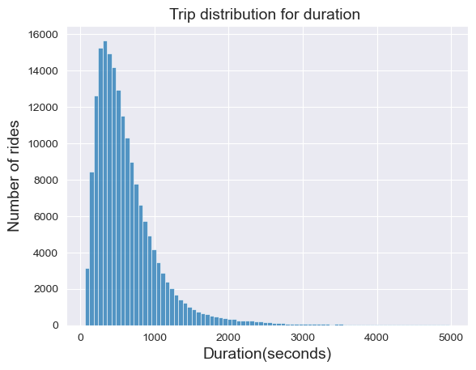

## Average duration for riders on days of the week

> The visual shows the average duration for each day and it is relatively low from Monday to Friday Compared to Saturday  
> and Sunday which is higher.

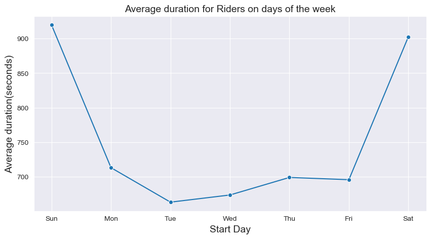

# Average duration for user type in a week

> The lineplot shows a comparison betweeen types of users and their average duration in a week.it is clear that customers lasted longer than subscribers on average.

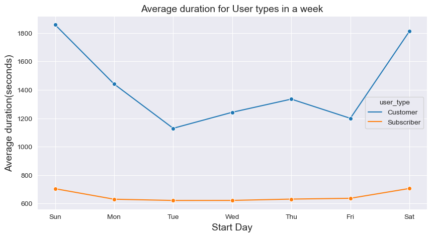